# Part I - (Ford GoBike System Data Exploration Analysis)

## Introduction

> Ford GoBike System Data: This data set contains information about individual rides made in Ford GoBike, a bike-sharing system covering the greater San Francisco Bay area, for the month of Feburary in the year 2019

## Preliminary Wrangling

```python
# import all packages and set plots to be embedded inline
import numpy as np
import pandas as pd
import matplotlib.pyplot as plt
from datetime import datetime
import seaborn as sb

%matplotlib inline
```

> Load in your dataset and describe its properties through the questions below. Try and motivate your exploration goals through this section.

```python
#load data in dataframe
data = pd.read_csv("201902-fordgobike-tripdata.csv")
```

### Programmatic Data Assessment

```python
#Check first rows of data
data.head()
```

|  | duration_sec | start_time | end_time | start_station_id | start_station_name | start_station_latitude | start_station_longitude | end_station_id | end_station_name | end_station_latitude | end_station_longitude | bike_id | user_type | member_birth_year | member_gender | bike_share_for_all_trip |
| --- | --- | --- | --- | --- | --- | --- | --- | --- | --- | --- | --- | --- | --- | --- | --- | --- |
| 0 | 52185 | 2019-02-28 17:32:10.1450 | 2019-03-01 08:01:55.9750 | 21.0 | Montgomery St BART Station (Market St at 2nd St) | 37.789625 | -122.400811 | 13.0 | Commercial St at Montgomery St | 37.794231 | -122.402923 | 4902 | Customer | 1984.0 | Male | No |
| 1 | 42521 | 2019-02-28 18:53:21.7890 | 2019-03-01 06:42:03.0560 | 23.0 | The Embarcadero at Steuart St | 37.791464 | -122.391034 | 81.0 | Berry St at 4th St | 37.775880 | -122.393170 | 2535 | Customer | NaN | NaN | No |
| 2 | 61854 | 2019-02-28 12:13:13.2180 | 2019-03-01 05:24:08.1460 | 86.0 | Market St at Dolores St | 37.769305 | -122.426826 | 3.0 | Powell St BART Station (Market St at 4th St) | 37.786375 | -122.404904 | 5905 | Customer | 1972.0 | Male | No |
| 3 | 36490 | 2019-02-28 17:54:26.0100 | 2019-03-01 04:02:36.8420 | 375.0 | Grove St at Masonic Ave | 37.774836 | -122.446546 | 70.0 | Central Ave at Fell St | 37.773311 | -122.444293 | 6638 | Subscriber | 1989.0 | Other | No |
| 4 | 1585 | 2019-02-28 23:54:18.5490 | 2019-03-01 00:20:44.0740 | 7.0 | Frank H Ogawa Plaza | 37.804562 | -122.271738 | 222.0 | 10th Ave at E 15th St | 37.792714 | -122.248780 | 4898 | Subscriber | 1974.0 | Male | Yes |

```python
#statisical information
data.describe()
```

|  | duration_sec | start_station_id | start_station_latitude | start_station_longitude | end_station_id | end_station_latitude | end_station_longitude | bike_id | member_birth_year |
| --- | --- | --- | --- | --- | --- | --- | --- | --- | --- |
| count | 183412.000000 | 183215.000000 | 183412.000000 | 183412.000000 | 183215.000000 | 183412.000000 | 183412.000000 | 183412.000000 | 175147.000000 |
| mean | 726.078435 | 138.590427 | 37.771223 | -122.352664 | 136.249123 | 37.771427 | -122.352250 | 4472.906375 | 1984.806437 |
| std | 1794.389780 | 111.778864 | 0.099581 | 0.117097 | 111.515131 | 0.099490 | 0.116673 | 1664.383394 | 10.116689 |
| min | 61.000000 | 3.000000 | 37.317298 | -122.453704 | 3.000000 | 37.317298 | -122.453704 | 11.000000 | 1878.000000 |
| 25% | 325.000000 | 47.000000 | 37.770083 | -122.412408 | 44.000000 | 37.770407 | -122.411726 | 3777.000000 | 1980.000000 |
| 50% | 514.000000 | 104.000000 | 37.780760 | -122.398285 | 100.000000 | 37.781010 | -122.398279 | 4958.000000 | 1987.000000 |
| 75% | 796.000000 | 239.000000 | 37.797280 | -122.286533 | 235.000000 | 37.797320 | -122.288045 | 5502.000000 | 1992.000000 |
| max | 85444.000000 | 398.000000 | 37.880222 | -121.874119 | 398.000000 | 37.880222 | -121.874119 | 6645.000000 | 2001.000000 |

```python
#shape of dataset
data.shape
```

```
(183412, 16)
```

```python
#information of data
data.info()
```

```
<class 'pandas.core.frame.DataFrame'>
RangeIndex: 183412 entries, 0 to 183411
Data columns (total 16 columns):
duration_sec               183412 non-null int64
start_time                 183412 non-null object
end_time                   183412 non-null object
start_station_id           183215 non-null float64
start_station_name         183215 non-null object
start_station_latitude     183412 non-null float64
start_station_longitude    183412 non-null float64
end_station_id             183215 non-null float64
end_station_name           183215 non-null object
end_station_latitude       183412 non-null float64
end_station_longitude      183412 non-null float64
bike_id                    183412 non-null int64
user_type                  183412 non-null object
member_birth_year          175147 non-null float64
member_gender              175147 non-null object
bike_share_for_all_trip    183412 non-null object
dtypes: float64(7), int64(2), object(7)
memory usage: 22.4+ MB
```

### Cleaning Data For Analysis

```python
#copy of dataframe
bike = data.copy()
```

> I created a copy of the dataframe because I did not want to alter the original data. I will convert the datatype of member_birth_year to integer as it will be used for calculation to generate an age feature, then I will extract the date from the start_time column, after which I will select only columns needed for analysis

```python
#convert type from object to integer and Nan to 0
bike['member_birth_year'] = bike['member_birth_year'].fillna(0).astype(int)
#generate age column
bike["age"] = bike["member_birth_year"].apply(lambda x: 2019 - x if x > 0 else 0)
```

```python
#extracting date of the month
bike['date'] = bike['start_time'].map(lambda x: x[:10])
bike['date'] = bike['date'].map(lambda x: datetime.strptime(x, '%Y-%m-%d'))
#selecting date from datetime
bike['date'] = bike['date'].map(lambda x: x.day)
```

> Next I will drop rows that have Nans and then select only columns I will be using for the analysis

```python
# drop Nans
biketrip = bike.dropna()
```

```python
biketrip = biketrip[['duration_sec', 'bike_id', 'user_type', 'age',  'member_gender', 'date', 'bike_share_for_all_trip']]
```

```python
#shape of dataframe
biketrip.head()
```

|  | duration_sec | bike_id | user_type | age | member_gender | date | bike_share_for_all_trip |
| --- | --- | --- | --- | --- | --- | --- | --- |
| 0 | 52185 | 4902 | Customer | 35 | Male | 28 | No |
| 2 | 61854 | 5905 | Customer | 47 | Male | 28 | No |
| 3 | 36490 | 6638 | Subscriber | 30 | Other | 28 | No |
| 4 | 1585 | 4898 | Subscriber | 45 | Male | 28 | Yes |
| 5 | 1793 | 5200 | Subscriber | 60 | Male | 28 | No |

```python
biketrip.info()
```

[output not shown]

### What is/are the main feature(s) of interest in your dataset?

> The main feature of interset in this Ford bike dataset is the duration_sec because my analysis is on how long each ride lasted and factors that determine durationog ride

### What features in the dataset do you think will help support your investigation into your feature(s) of interest?

> user_type, age, member_gender, date and bike_share_for_all_trip will support my investigation as it will give me insights on which gender, user type took longer rides and if age and bike sharing makes trips last longer

## Univariate Exploration

> In this section, I will investigate the distributions of individual variables to see how each feature is distributed. I will start with the main feature of interest duration_sec

#### Duration_sec

> How is duration_sec distributed? I will start by plotting a histogram to show distribution of duration_sec

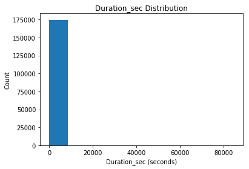

```python
plt.hist(data=biketrip, x='duration_sec')
plt.xlabel('Duration_sec (seconds)')
plt.ylabel('Count')
plt.title('Duration_sec Distribution');
```

> from the histogram above, I can not gather any intelligent insight, so I will change the x axis to logarithmic scale to see if there will be change

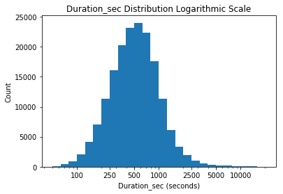

```python
cut = 10 ** np.arange(1.7, 4.3+0.1, 0.1)
plt.hist(data=biketrip, x='duration_sec', bins=cut)
plt.xscale('log')
plt.xticks([100, 250, 500, 1000, 2500, 5000, 10000],[100,250, 500, 1000, 2500,5000, 10000] )
plt.xlabel('Duration_sec (seconds)')
plt.ylabel('Count')
plt.title('Duration_sec Distribution Logarithmic Scale');
```

> After transfroming the x axis scale into logarithmic scale, the histogram is now understandable as I can gather knowlegdeable insights from it. The Duration_sec feature is unimodal, having one peak around 500-600 seconds and it is also fairly symmetrical. I am really curious on factors that contribute to duration_sec distibution. I can also see there are outliers, so I will replace the extreme values with the mean of duration_sec

```python
#Cleaning outliers
Q25 = biketrip['duration_sec'].quantile(0.25)
Q75= biketrip['duration_sec'].quantile(0.75)
diff = Q75 - Q25
# detect extereme values
Q1 = (biketrip['duration_sec'] > (Q75 + 1.5 * diff))
extereme = biketrip['duration_sec'][~Q1].max()
#replace with mean
biketrip['duration_sec'] = np.where(biketrip['duration_sec']> extereme, biketrip['duration_sec'].mean() , biketrip['duration_sec'])
```

> After looking at the main feature of interest, I will now start looking at the distibution of the other feature

#### Date

> Which days were more rides taken? I want to look at the distribution of rides across the 28 days of the month of feburary to get an insights on days that most rides were taken and if there where days with no rides at all

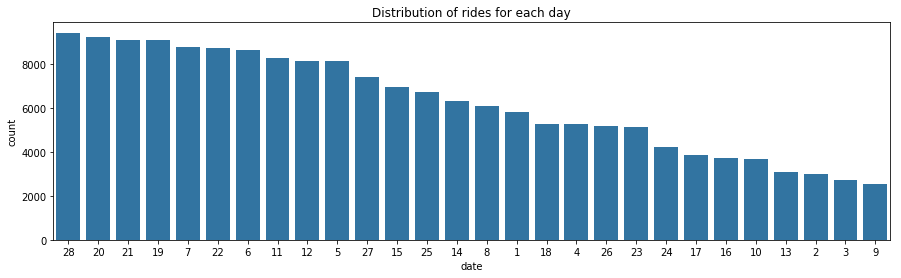

```python
#bar chart to show distribution of rides across the days
plt.figure(figsize=[15, 4])
desc = biketrip['date'].value_counts().index
blue = sb.color_palette()[0]
sb.countplot(data=biketrip, x='date', color=blue, order= desc)
plt.title('Distribution of rides for each day');
```

> From the graph, It is obvious that rides were taken everyday. On the 28th day of feburary, the most rides were taken for the month. The least count of rides was on the 9th of feburary. Futher investigations will be needed to find out if the weather was unfavorable on that day

#### Age

> What is the age distribution of riders? I will like to see the age distribution of the riders, are the generally young or old?

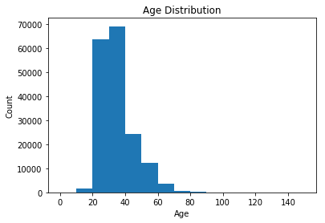

```python
#plotting histogram to show age distribution
bins = np.arange(0, biketrip['age'].max()+10, 10)
plt.hist(data = biketrip, x = 'age', bins = bins)
plt.xlabel('Age')
plt.ylabel('Count')
plt.title('Age Distribution');
```

> I will use a smaller bin size and also limit the x axis to have a better look at the distribution as there might be hidden important information

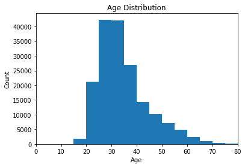

```python
# using smaller bin and limiting x axis
bins = np.arange(0, biketrip['age'].max()+5, 5)
plt.hist(data = biketrip, x = 'age', bins = bins)
plt.xlim((0,80))
plt.xlabel('Age')
plt.ylabel('Count')
plt.title('Age Distribution');
```

```python
#filtering out extreme values
biketrip = biketrip[biketrip['age'] < 80]
```

#### Member_gender

> How is the member_gender feature distributed?

```python
# function to plot graph
def Visualize(feature, title):
    """ Visualize distribution of the feature"""
    #select a color to display
    color = sb.color_palette()[0]
    #ordering bars
    desc = biketrip[feature].value_counts().index
    #barchart
    sb.countplot(data=biketrip, x=feature, color=color, order=desc)
    plt.title(title);
    #calculate percentage
    total = biketrip[feature].value_counts().sum()
    unit = biketrip[feature].value_counts()
    #generate label and ticks
    locs,labels = plt.xticks()
    ticks = zip(locs,labels)
    # to display percentage of the different categories
    for loc, label in ticks:
        x = unit[label.get_text()]
        percent = '{:0.1f}%'.format(100*x/total)
        plt.text(loc,x+2,percent, ha='center',color='black')
```

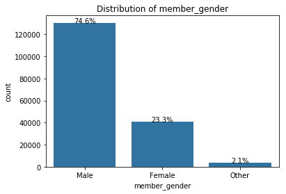

```python
#generate bar chart for member_gender
Visualize('member_gender', 'Distribution of member_gender')
```

> From the visualization, I can clearly see that the male gender is predominant having a very large share of the rider's population, It is even more than the female and other gender combined. The percentage of Male gender is 74.6%, while that of Female is 23.3%. The Other gender comes last with 2.1%. Are the male riders responsible for the duration_sec peak? Do they take longer rides? I will find later in the analysis

#### User_type

> What is the distribution of user_type? Which category of user_type are there and which has the larger share? I will plot a bar chart showing this distribution.

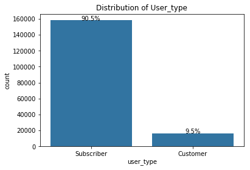

```python
#barchart to show distribution of user_type
Visualize('user_type', 'Distribution of User_type')
```

> There are two categories of user_type, the subscribers and the customers as seen from the bar chart. The subscriber is predominat having a percentage of 90.5. The customer category is the minority with as little as 9.5%. Are the subscriber's responsible for the duration_sec peak? Do subscribers take longer ride than customers? I will find out later in the analysis.

#### Bike_share_for_all_trip

> What is the distribution of bike_share_for_all_trip? How many categories are there and how are they distributed?

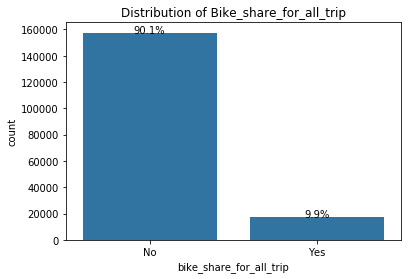

```python
#generate bar chart for bike_share_for_all_trip
Visualize('bike_share_for_all_trip', 'Distribution of Bike_share_for_all_trip')
```

> From the bar chart that was generated, it is obvoius that there are only two categories for this feature, No and Yes and they are not equally distributed. The No is predominant with 90.1% compared to Yes category that has just 9.9%. Why are there more rides that bikes were not shared? and does bike sharing affect the duration of a ride?

### Discuss the distribution(s) of your variable(s) of interest. Were there any unusual points? Did you need to perform any transformations?

> The distribution of duration_sec and age was unimodal. For duration_sec, I transformed the x axis to logarithmic scale and I also limited the x axis and reduced the bin size for age before I could get Insight

### Of the features you investigated, were there any unusual distributions? Did you perform any operations on the data to tidy, adjust, or change the form of the data? If so, why did you do this?

> Both the duration_sec and age needed cleaning as there were outliers present in the data.I had to clean out the outliers so I can get accurate analysis and vusualization

## Bivariate Exploration

> Here, I will investigate the bi-relationship between the variables look at during the univariate expolration. I want to know how they are related and draw further insights from my data. I will start by looking at the relationship of the main feature of interest duration sec with other variables

#### Duration_sec and User_type

> What is the relationship between duration_sec and users? Which category of user_type took longer rides in the month of feburary?

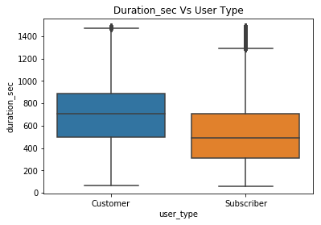

```python
# box plot
sb.boxplot(data = biketrip, x = 'user_type',y = 'duration_sec')
plt.title('Duration_sec Vs User Type');
```

Surprisingly, I can see from the box plot that customers took longer rides than the subscribers, although the population of the customer is only 9.5% as seen in the univariate exploration. The mean and inter-quartile range of the box plot for customer is higher than that of the subscribers which means that customers took longer rides? If customers pay higher ride fee than subscribers, this might be the reason why they are taking longer rides

#### Duration_sec and Age

> What is the relationship between duration_sec and age?, Do younger riders take longer rides?, are they responsible for the peak in the distribution of duration_sec?. I will look at this relationship using a scatter plot.

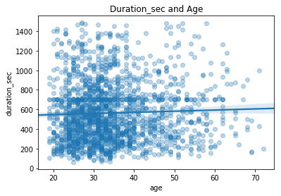

```python
# sample dataset
bike_samp = biketrip.sample(n=2000, replace = False)
# generate scatterplot
sb.regplot(data = bike_samp, x = 'age', y = 'duration_sec',scatter_kws={'alpha':0.3})
plt.title('Duration_sec and Age');
```

> I plotted a scatterplot using a sample of the dataset and I can see a weak positive corrolation. This is not what I expected as I anticipated a strong negative corrolation showing that duration_sec reduced with age. As seen earlier from the univariate exploration of age, a large population of riders are 20-40 years old, This is evident from the dark area of the scatter plot showing concentration of riders

#### Duration_sec and member_gender

> What is the relationship between duration_sec and member_gender? Which category of member_gender took longer rides? I will generate a boxplot to visualize the relationship.

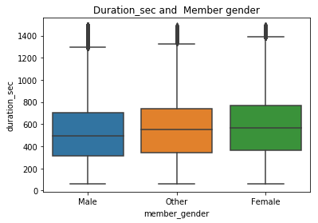

```python
#boxplot
sb.boxplot(data = biketrip, x = 'member_gender',y = 'duration_sec')
plt.title('Duration_sec and  Member gender');
```

> From the box plot generated, the inter-quartile range for female is the highest while that of male is the lowest. This means that female riders took longer rides compared to the other genders. Recall that from the univariate exploration of member_gender, the male category accounted for a very large share of the population with a percentage of 74.6%. Yet, the male riders took the shortest rides when compared to other genders

#### Date and Member_gender

> Where there days that only one category of member_gender took rides?

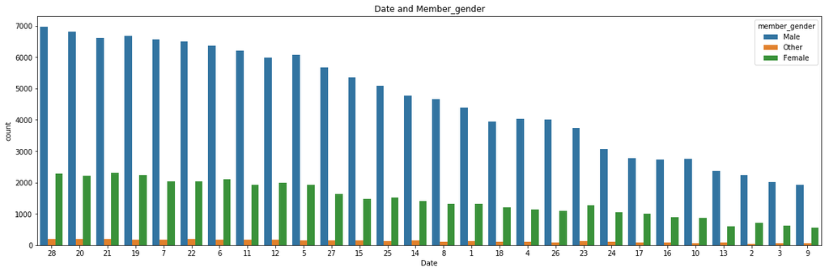

```python
#bar chart
plt.figure(figsize=[20, 6])
desc = biketrip['date'].value_counts().index
sb.countplot(data=biketrip, x='date', hue='member_gender',order=desc)
plt.xlabel('Date')
plt.title('Date and Member_gender');
```

> From the multiple bar chart generated, I can see that there was no day when only one category of member_gender took rides. All the three categories namely male, female and other all took rides for each day of the month of Feburary. As shown in the univariate expolration of member_gender, it is also obvious that a very large population of the riders are male

#### Date and User_type

> Where there days having only one categories of user_type? Was there any day in the month of feburary that only customers took rides?

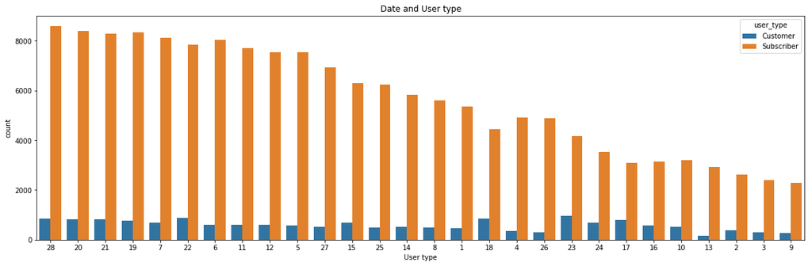

```python
#bar chart
plt.figure(figsize=[20, 6])
desc = biketrip['date'].value_counts().index
sb.countplot(data=biketrip, x='date', hue='user_type',order=desc)
plt.xlabel('User type')
plt.title('Date and User type');
```

> From the bar chart, I can see that through out the month of feburary both the customer and subscriber category of user_type took rides.I already know from the univariate exploration of user_type that subscribers have a larger share of the population of the rides. This is also visible in the multiple bar chart.

#### Age and member_gender

> What is the relationship between age and member_gender? Which category of member_gender are younger or older?

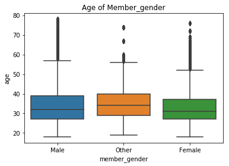

```python
#generate boxplot
sb.boxplot(data = biketrip, x = 'member_gender',y = 'age')
plt.title('Age of Member_gender');
```

> From the box plot, the inter-quartile range of the female category is lower meaning that the female riders are relatively younger. The other category inter-quartile range and mean is the highest when compared to the other categories, meaning that the other riders are relatively older.Recall that from the bivariate relationship of duration_sec and member_gender, Female riders took longer rides, this could be because the female riders are relatively younger

#### Age and User_type

> Which category of user_type are younger? Are the customers younger? Are the subscribers older?

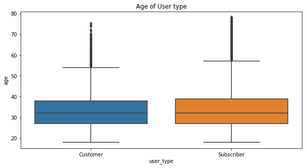

```python
#  generate box plot
plt.figure(figsize=[10, 5])
sb.boxplot(data = biketrip, x = 'user_type',y = 'age')
plt.title('Age of User type');
```

#### Member_gender and User_type

> How is the relationship of member_gender and user_type? Which category of member_gender are customers or subscribers and vice versa?

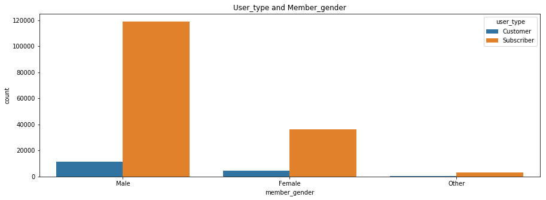

```python
# bar chart
#ordering chart
plt.figure(figsize=[15, 5])
desc = biketrip['member_gender'].value_counts().index
sb.countplot(data = biketrip, x = 'member_gender', hue = 'user_type', order=desc)
plt.title('User_type and Member_gender');
```

> From the multiple bar chart, all the categories of member_gender are both customers and subscribers. The male category of member gender have the highest count of both customer and subscriber category of user_type

### Talk about some of the relationships you observed in this part of the investigation. How did the feature(s) of interest vary with other features in the dataset?

> Duration_sec is the main feature of interest and I observed after the bivariate exploration of the features that the customer category of user_type and the female category of the member_gender took longer rides.

## Multivariate Exploration

> I will create a graph showing the relationship between three different variables in the multivariate exploration

#### Duration_sec, Bike_share and User_type

> How are these three features related? Do riders take longer rides when bike is shared? Which category of User_type share bike?

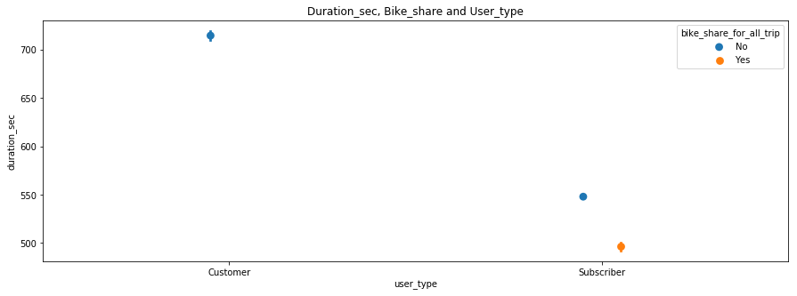

```python
#generate pointplot
plt.figure(figsize=[15, 5])
ax = sb.pointplot(data = biketrip, x = 'user_type', y = 'duration_sec', hue = 'bike_share_for_all_trip',
                  dodge = 0.1, linestyles = "")
plt.title('Duration_sec, Bike_share and User_type');
```

> From the pointplot above, only the subscriber category of user_type share rides and rides where bike were shared had the lowest duration_sec. So sharing bike does not increase the duration of a trip

#### Duration_sec, Member_gender and User_type

> Which of the categories of both meber_gender and user_type took longer rides?

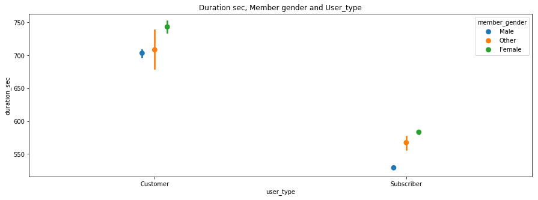

```python
#point plot
plt.figure(figsize=[15, 5])
ax = sb.pointplot(data = biketrip, x = 'user_type', y = 'duration_sec', hue = 'member_gender',
                  dodge = 0.1, linestyles = "")
plt.title('Duration sec, Member gender and User_type');
```

> From the pointplot above the female customers took longest rides than any other category of riders.

### Talk about some of the relationships you observed in this part of the investigation. Were there features that strengthened each other in terms of looking at your feature(s) of interest?

> The bike_share_for_all_trip, member_gender, user_type and the main feature of interest strengthened each other as they reinforced the insights that were gotten from the observation